# Cleaning Clinical Research Data in R

How to turn a messy spreadsheet into an analysis-ready dataset

Author

RISE Education Team

**NoteHow to use this article**

This article is designed for medical students and early-stage researchers who are new to R.

You can read it as a normal article, or you can copy the code chunks into RStudio and run them step by step.

## 1. Why data cleaning matters in medical research

Real research datasets are rarely clean. A spreadsheet may look organised at first glance, but it can still contain problems that quietly damage the analysis.

Common examples include:

- inconsistent column names;
- missing values;
- duplicate participants;
- inconsistent category labels;
- impossible biological values;
- numbers accidentally stored as text;
- unclear variable coding.

In medical research, data cleaning is not just administrative work. It is part of the scientific method. Before asking, “Which statistical test should I run?”, we first need to ask, “Can I trust this dataset?”

R is useful because every cleaning step can be written as code. This means the work can be checked, repeated, improved, and shared with supervisors or collaborators.

**TipMain idea**

Do not overwrite the raw dataset. Keep the original file untouched, write your cleaning steps in code, and save a cleaned version separately.

## 2. The messy sample dataset

In this article, we will use a fictional teaching dataset called `rise_sample_health_data_messy.csv`.

The dataset contains participant-level health data with deliberate problems added for teaching purposes.

| Variable | What it represents | Example problem |
| --- | --- | --- |
| `Participant ID` | Participant identifier | Extra spaces and duplicate IDs |
| `Age` | Age in years | Missing values or impossible values such as 250 |
| `Sex` | Sex recorded in the dataset | `Male`, `male`, `M`, `F`, unclear values |
| `BMI` | Body mass index | Missing values or impossible values |
| `Systolic BP` | Systolic blood pressure | Values written as text, such as `142 mmHg` |
| `HbA1c (mmol/mol)` | HbA1c | Values written as text, such as `48 mmol/mol` |
| `Smoking Status` | Smoking history | Inconsistent labels such as `Never`, `N`, `ex-smoker` |
| `Diabetes Status` | Diabetes status | Inconsistent labels such as `Yes`, `Y`, `T2DM`, `No` |

The aim is to turn this messy dataset into an analysis-ready dataset.

## 3. Recommended project folder structure

A clean folder structure makes research code much easier to manage.

```
article_02_data_cleaning/
├── article_02_cleaning_clinical_research_data.qmd
├── data_raw/
│   └── rise_sample_health_data_messy.csv
├── data_cleaned/
│   └── rise_sample_health_data_cleaned.csv
├── scripts/
│   └── article_02_cleaning_code.R
└── outputs/
    ├── data_cleaning_summary.csv
    ├── duplicate_participant_report.csv
    ├── missing_value_summary.csv
    ├── suspicious_values_report.csv
    └── variable_dictionary.csv
```

The key idea is simple:

- `data_raw/` contains the original dataset;
- `data_cleaned/` contains the cleaned dataset;
- `scripts/` contains reusable R code;
- `outputs/` contains useful reports generated during cleaning.

## 4. Load packages

We will use two main packages.

- `tidyverse` helps us import, clean, summarise, and visualise data.
- `janitor` helps us clean column names and create quick tables.

You only need to install packages once:

```r
# Run this only if the packages are not already installed.
install.packages("tidyverse")
install.packages("janitor")
```

Load the packages each time you start a new R session:

```r
library(tidyverse)
library(janitor)
```

## 5. Create folders for cleaned data and outputs

Before saving files later, we should make sure the output folders exist.

```r
# Create folders if they do not already exist.
# showWarnings = FALSE prevents R from complaining if the folder already exists.
dir.create("data_cleaned", showWarnings = FALSE)
dir.create("outputs", showWarnings = FALSE)
```

## 6. Import the raw dataset

We will import the raw CSV file from the `data_raw/` folder.

This time, we intentionally import all columns as text first. This is a safe beginner-friendly approach for messy datasets because it allows us to inspect the data before forcing R to treat variables as numeric or categorical.

```r
# Store the raw data path in one object.
# This makes the file path easier to reuse and update.
raw_data_path <- "data_raw/rise_sample_health_data_messy.csv"

# Check that the file exists before trying to read it.
# This gives a clearer error message if the file is in the wrong folder.
if (!file.exists(raw_data_path)) {
  stop("Cannot find the raw dataset. Check that it is inside the data_raw/ folder.")
}

# Import the dataset.
# col_types = cols(.default = col_character()) keeps all columns as text at first.
# This is useful when a messy column contains mixed values such as '142 mmHg'.
raw_data <- read_csv(
  file = raw_data_path,
  col_types = cols(.default = col_character()),
  na = c("", "NA", "N/A", "Unknown", "Not recorded", "not available")
)
```

## 7. Inspect the raw dataset

Before cleaning anything, we should inspect the dataset.

```r
# Look at the first few rows.
head(raw_data)
```

```
# A tibble: 6 × 13
  `Participant ID` Age   Sex    BMI   `Systolic BP` `Diastolic BP`
  <chr>            <chr> <chr>  <chr> <chr>         <chr>
1 P001             69    Female 16.5  102           90
2 P002             32    Male   33.3  101           99
3 P003             <NA>  Male   26.9  161           74
4 P004             38    Female 26.9  111           55
5 P005             41    Female 31.1  127           62
6 P006             20    Female <NA>  142           100
# ℹ 7 more variables: `HbA1c (mmol/mol)` <chr>, `Smoking Status` <chr>,
#   `Exercise Minutes Per Week` <chr>, `Diabetes Status` <chr>,
#   `Study Group` <chr>, `Recruitment Site` <chr>, Notes <chr>
```

```r
# Check the structure of the dataset.
glimpse(raw_data)
```

```
Rows: 73
Columns: 13
$ `Participant ID`            <chr> "P001", "P002", "P003", "P004", "P005", "P…
$ Age                         <chr> "69", "32", NA, "38", "41", "20", "39", "7…
$ Sex                         <chr> "Female", "Male", "Male", "Female", "Femal…
$ BMI                         <chr> "16.5", "33.3", "26.9", "26.9", "31.1", NA…
$ `Systolic BP`               <chr> "102", "101", "161", "111", "127", "142", …
$ `Diastolic BP`              <chr> "90", "99", "74", "55", "62", "100", "70",…
$ `HbA1c (mmol/mol)`          <chr> "82", "30", "39", "53", "43", "78", "64", …
$ `Smoking Status`            <chr> "current smoker", "never smoker", "Never",…
$ `Exercise Minutes Per Week` <chr> "167", "169", "392", "282", "121", "193", …
$ `Diabetes Status`           <chr> "T2DM", "Yes", "No", "No", "No", NA, "T2DM…
$ `Study Group`               <chr> "Intervention", "Intervention", "intervent…
$ `Recruitment Site`          <chr> "WESTMEAD", "RPA", "Royal North Shore", NA…
$ Notes                       <chr> "baseline visit", NA, "manual entry", "bas…
```

```r
# Check the number of rows and columns.
dim(raw_data)
```

```
[1] 73 13
```

```r
# Check the original column names.
names(raw_data)
```

```
 [1] "Participant ID"            "Age"
 [3] "Sex"                       "BMI"
 [5] "Systolic BP"               "Diastolic BP"
 [7] "HbA1c (mmol/mol)"          "Smoking Status"
 [9] "Exercise Minutes Per Week" "Diabetes Status"
[11] "Study Group"               "Recruitment Site"
[13] "Notes"
```

These commands help us answer:

- How many rows and columns are there?
- What are the variable names?
- Are the variable names easy to use in R?
- Are numeric variables currently stored as text?
- Do any values already look strange?

## 8. Count missing values before cleaning

A missing value means that the data point is not available. In R, missing values are usually represented as `NA`.

```r
# Count missing values in each column of the raw dataset.
missing_before_cleaning <- raw_data %>%
  summarise(across(everything(), ~ sum(is.na(.x)))) %>%
  pivot_longer(
    cols = everything(),
    names_to = "variable",
    values_to = "missing_n"
  ) %>%
  arrange(desc(missing_n))

missing_before_cleaning
```

```
# A tibble: 13 × 2
   variable                  missing_n
   <chr>                         <int>
 1 Notes                            37
 2 Smoking Status                    7
 3 Recruitment Site                  5
 4 Sex                               4
 5 Diabetes Status                   4
 6 Study Group                       3
 7 Age                               2
 8 BMI                               1
 9 HbA1c (mmol/mol)                  1
10 Participant ID                    0
11 Systolic BP                       0
12 Diastolic BP                      0
13 Exercise Minutes Per Week         0
```

What is happening here?

- `summarise()` creates summary values.
- `across(everything(), ...)` applies the same calculation to every column.
- `is.na()` checks whether a value is missing.
- `sum(is.na(.x))` counts how many missing values are in each column.
- `pivot_longer()` turns the result into a cleaner table.

## 9. Clean column names

Raw spreadsheets often have column names with spaces, capital letters, and brackets. These are readable for humans but annoying to use in R.

For example, `Systolic BP` becomes easier to use after being cleaned to `systolic_bp`.

```r
# clean_names() converts column names to a consistent R-friendly style.
# For example, 'Systolic BP' becomes 'systolic_bp'.
clean_data <- raw_data %>%
  clean_names()

# Compare the cleaned column names.
names(clean_data)
```

```
 [1] "participant_id"            "age"
 [3] "sex"                       "bmi"
 [5] "systolic_bp"               "diastolic_bp"
 [7] "hb_a1c_mmol_mol"           "smoking_status"
 [9] "exercise_minutes_per_week" "diabetes_status"
[11] "study_group"               "recruitment_site"
[13] "notes"
```

This is usually one of the first cleaning steps in a project.

## 10. Clean participant IDs and text spacing

Before checking for duplicate participants, we should clean the participant IDs.

For example, `" P024 "` and `"P024"` should be treated as the same participant.

```r
clean_data <- clean_data %>%
  mutate(
    # Remove extra spaces and convert IDs to uppercase.
    participant_id = str_squish(participant_id),
    participant_id = str_to_upper(participant_id),

    # Remove unnecessary spaces from all other text columns.
    across(where(is.character), str_squish)
  )
```

Useful functions:

- `str_squish()` removes extra spaces;
- `str_to_upper()` converts text to uppercase;
- `across(where(is.character), ...)` applies a function to all text columns.

## 11. Check duplicate participants

A duplicate participant means the same participant ID appears more than once.

Duplicates are common in real datasets. They can happen because of repeated data entry, merging datasets, or exporting data from multiple sources.

```r
# Count how many times each participant ID appears.
duplicate_participants <- clean_data %>%
  count(participant_id, name = "n_rows") %>%
  filter(n_rows > 1)

duplicate_participants
```

```
# A tibble: 3 × 2
  participant_id n_rows
  <chr>           <int>
1 P010                2
2 P024                2
3 P040                2
```

**WarningImportant caution**

In a real research project, do not delete duplicates automatically without checking why they exist. Sometimes a repeated ID may represent a genuine repeated visit or follow-up record. In this teaching dataset, each row is meant to represent one participant, so we will keep one row per participant.

```r
# Keep one row for each participant ID.
# .keep_all = TRUE keeps the other variables from the first matching row.
clean_data <- clean_data %>%
  distinct(participant_id, .keep_all = TRUE)
```

## 12. Convert numeric variables

Some variables should be numeric, but they may have been imported as text because the raw column contained values such as `"142 mmHg"` or `"48 mmol/mol"`.

We can use `parse_number()` to extract the numeric part of a value.

```r
clean_data <- clean_data %>%
  mutate(
    age = parse_number(age),
    bmi = parse_number(bmi),
    systolic_bp = parse_number(systolic_bp),
    diastolic_bp = parse_number(diastolic_bp),
    hba1c_mmol_mol = parse_number(hb_a1c_mmol_mol),
    exercise_minutes_per_week = parse_number(exercise_minutes_per_week)
  )
```

Now check the structure again:

```r
glimpse(clean_data)
```

```
Rows: 70
Columns: 14
$ participant_id            <chr> "P001", "P002", "P003", "P004", "P005", "P00…
$ age                       <dbl> 69, 32, NA, 38, 41, 20, 39, 70, 19, 47, 55, …
$ sex                       <chr> "Female", "Male", "Male", "Female", "Female"…
$ bmi                       <dbl> 16.5, 33.3, 26.9, 26.9, 31.1, NA, 23.2, 29.3…
$ systolic_bp               <dbl> 102, 101, 161, 111, 127, 142, 170, 153, 116,…
$ diastolic_bp              <dbl> 90, 99, 74, 55, 62, 100, 70, 68, 66, 77, 69,…
$ hb_a1c_mmol_mol           <chr> "82", "30", "39", "53", "43", "78", "64", "4…
$ smoking_status            <chr> "current smoker", "never smoker", "Never", "…
$ exercise_minutes_per_week <dbl> 167, 169, 392, 282, 121, 193, 4, 28, 164, 33…
$ diabetes_status           <chr> "T2DM", "Yes", "No", "No", "No", NA, "T2DM",…
$ study_group               <chr> "Intervention", "Intervention", "interventio…
$ recruitment_site          <chr> "WESTMEAD", "RPA", "Royal North Shore", NA, …
$ notes                     <chr> "baseline visit", NA, "manual entry", "basel…
$ hba1c_mmol_mol            <dbl> 82, 30, 39, 53, 43, 78, 64, 49, 84, 56, 41, …
```

Numeric variables are needed for means, medians, graphs, and many statistical tests.

## 13. Standardise categorical variables

Categorical variables often contain inconsistent labels.

For example, diabetes status might be recorded as `Yes`, `Y`, `T2DM`, `No`, `N`, or `no diabetes`.

The goal is to turn these messy labels into consistent categories.

### Clean sex

```r
clean_data <- clean_data %>%
  mutate(
    sex = str_to_lower(sex),
    sex = case_when(
      sex %in% c("male", "m", "man") ~ "Male",
      sex %in% c("female", "f", "woman") ~ "Female",
      TRUE ~ NA_character_
    )
  )

clean_data %>% count(sex)
```

```
# A tibble: 3 × 2
  sex        n
  <chr>  <int>
1 Female    34
2 Male      31
3 <NA>       5
```

### Clean smoking status

```r
clean_data <- clean_data %>%
  mutate(
    smoking_status = str_to_lower(smoking_status),
    smoking_status = case_when(
      smoking_status %in% c("never", "never smoker", "n") ~ "Never",
      smoking_status %in% c("former", "ex-smoker", "ex smoker", "f", "quit") ~ "Former",
      smoking_status %in% c("current", "current smoker", "c") ~ "Current",
      TRUE ~ NA_character_
    )
  )

clean_data %>% count(smoking_status)
```

```
# A tibble: 4 × 2
  smoking_status     n
  <chr>          <int>
1 Current           13
2 Former            20
3 Never             30
4 <NA>               7
```

### Clean diabetes status

```r
clean_data <- clean_data %>%
  mutate(
    diabetes_status = str_to_lower(diabetes_status),
    diabetes_status = case_when(
      diabetes_status %in% c("yes", "y", "t2dm", "type 2 diabetes") ~ "Yes",
      diabetes_status %in% c("no", "n", "no diabetes") ~ "No",
      TRUE ~ NA_character_
    )
  )

clean_data %>% count(diabetes_status)
```

```
# A tibble: 3 × 2
  diabetes_status     n
  <chr>           <int>
1 No                 39
2 Yes                26
3 <NA>                5
```

### Clean study group and recruitment site

```r
clean_data <- clean_data %>%
  mutate(
    study_group = str_to_lower(study_group),
    study_group = case_when(
      study_group %in% c("control", "c") ~ "Control",
      study_group %in% c("intervention", "i") ~ "Intervention",
      TRUE ~ NA_character_
    ),

    recruitment_site = str_to_lower(recruitment_site),
    recruitment_site = case_when(
      recruitment_site == "rpa" ~ "RPA",
      recruitment_site == "westmead" ~ "Westmead",
      recruitment_site == "concord" ~ "Concord",
      recruitment_site == "royal north shore" ~ "Royal North Shore",
      TRUE ~ NA_character_
    )
  )

clean_data %>% count(study_group)
```

```
# A tibble: 3 × 2
  study_group      n
  <chr>        <int>
1 Control         25
2 Intervention    41
3 <NA>             4
```

```r
clean_data %>% count(recruitment_site)
```

```
# A tibble: 5 × 2
  recruitment_site      n
  <chr>             <int>
1 Concord              14
2 RPA                  18
3 Royal North Shore    12
4 Westmead             21
5 <NA>                  5
```

Useful functions:

- `str_to_lower()` reduces problems caused by inconsistent capitalisation;
- `case_when()` recodes messy values into standard categories;
- `TRUE ~ NA_character_` means that anything unexpected becomes missing for review.

## 14. Check impossible or suspicious values

A value can be numeric but still biologically implausible.

For example:

- age of 250 years;
- BMI of 5 kg/m^2;
- systolic blood pressure of 310 mmHg;
- negative exercise minutes.

For this teaching dataset, we will use simple example cut-offs. These are not universal clinical rules. In a real project, cleaning decisions should be discussed with your supervisor and documented.

```r
# Create a report of values that look suspicious.
suspicious_values <- bind_rows(
  clean_data %>% filter(age < 0) %>% transmute(participant_id, variable = "age", value = as.character(age), issue = "Age is below 0 years"),
  clean_data %>% filter(age > 120) %>% transmute(participant_id, variable = "age", value = as.character(age), issue = "Age is above 120 years"),
  clean_data %>% filter(bmi < 10) %>% transmute(participant_id, variable = "bmi", value = as.character(bmi), issue = "BMI is below 10 kg/m^2"),
  clean_data %>% filter(bmi > 80) %>% transmute(participant_id, variable = "bmi", value = as.character(bmi), issue = "BMI is above 80 kg/m^2"),
  clean_data %>% filter(systolic_bp < 70) %>% transmute(participant_id, variable = "systolic_bp", value = as.character(systolic_bp), issue = "Systolic BP is below 70 mmHg"),
  clean_data %>% filter(systolic_bp > 250) %>% transmute(participant_id, variable = "systolic_bp", value = as.character(systolic_bp), issue = "Systolic BP is above 250 mmHg"),
  clean_data %>% filter(diastolic_bp < 40) %>% transmute(participant_id, variable = "diastolic_bp", value = as.character(diastolic_bp), issue = "Diastolic BP is below 40 mmHg"),
  clean_data %>% filter(diastolic_bp > 150) %>% transmute(participant_id, variable = "diastolic_bp", value = as.character(diastolic_bp), issue = "Diastolic BP is above 150 mmHg"),
  clean_data %>% filter(hba1c_mmol_mol < 15) %>% transmute(participant_id, variable = "hba1c_mmol_mol", value = as.character(hba1c_mmol_mol), issue = "HbA1c is below 15 mmol/mol"),
  clean_data %>% filter(hba1c_mmol_mol > 160) %>% transmute(participant_id, variable = "hba1c_mmol_mol", value = as.character(hba1c_mmol_mol), issue = "HbA1c is above 160 mmol/mol"),
  clean_data %>% filter(exercise_minutes_per_week < 0) %>% transmute(participant_id, variable = "exercise_minutes_per_week", value = as.character(exercise_minutes_per_week), issue = "Exercise minutes are below 0"),
  clean_data %>% filter(exercise_minutes_per_week > 2000) %>% transmute(participant_id, variable = "exercise_minutes_per_week", value = as.character(exercise_minutes_per_week), issue = "Exercise minutes are above 2000 per week")
)

suspicious_values
```

```
# A tibble: 8 × 4
  participant_id variable                  value issue
  <chr>          <chr>                     <chr> <chr>
1 P036           age                       -4    Age is below 0 years
2 P018           age                       250   Age is above 120 years
3 P021           bmi                       5     BMI is below 10 kg/m^2
4 P039           bmi                       91    BMI is above 80 kg/m^2
5 P024           systolic_bp               310   Systolic BP is above 250 mmHg
6 P027           diastolic_bp              22    Diastolic BP is below 40 mmHg
7 P046           diastolic_bp              180   Diastolic BP is above 150 mmHg
8 P033           exercise_minutes_per_week -30   Exercise minutes are below 0
```

## 15. Replace impossible values with missing values

For this article, we will replace clearly impossible values with `NA`.

This does not mean the value is unimportant. It means the value should not be used as if it were correct.

```r
clean_data <- clean_data %>%
  mutate(
    age = if_else(age < 0 | age > 120, NA_real_, age),
    bmi = if_else(bmi < 10 | bmi > 80, NA_real_, bmi),
    systolic_bp = if_else(systolic_bp < 70 | systolic_bp > 250, NA_real_, systolic_bp),
    diastolic_bp = if_else(diastolic_bp < 40 | diastolic_bp > 150, NA_real_, diastolic_bp),
    hba1c_mmol_mol = if_else(hba1c_mmol_mol < 15 | hba1c_mmol_mol > 160, NA_real_, hba1c_mmol_mol),
    exercise_minutes_per_week = if_else(exercise_minutes_per_week < 0 | exercise_minutes_per_week > 2000, NA_real_, exercise_minutes_per_week)
  )
```

Why use `NA_real_`?

- `NA` means missing value.
- `NA_real_` specifically means a missing numeric value.
- This keeps the variable type consistent.

## 16. Count missing values after cleaning

After cleaning, we should check how many missing values remain.

```r
missing_after_cleaning <- clean_data %>%
  summarise(across(everything(), ~ sum(is.na(.x)))) %>%
  pivot_longer(
    cols = everything(),
    names_to = "variable",
    values_to = "missing_n"
  ) %>%
  mutate(
    missing_percent = round(missing_n / nrow(clean_data) * 100, 1)
  ) %>%
  arrange(desc(missing_n))

missing_after_cleaning
```

```
# A tibble: 14 × 3
   variable                  missing_n missing_percent
   <chr>                         <int>           <dbl>
 1 notes                            37            52.9
 2 smoking_status                    7            10
 3 sex                               5             7.1
 4 diabetes_status                   5             7.1
 5 recruitment_site                  5             7.1
 6 study_group                       4             5.7
 7 age                               3             4.3
 8 bmi                               3             4.3
 9 systolic_bp                       2             2.9
10 diastolic_bp                      2             2.9
11 exercise_minutes_per_week         2             2.9
12 hb_a1c_mmol_mol                   1             1.4
13 hba1c_mmol_mol                    1             1.4
14 participant_id                    0             0
```

This table is useful because it shows which variables may need more careful discussion before analysis.

## 17. Create a simple cleaning summary

A good cleaning workflow should leave a short record of what happened.

```r
data_cleaning_summary <- tibble(
  step = c(
    "Raw dataset",
    "After removing duplicate participants",
    "After cleaning impossible values"
  ),
  number_of_rows = c(
    nrow(raw_data),
    nrow(clean_data),
    nrow(clean_data)
  ),
  number_of_columns = c(
    ncol(raw_data),
    ncol(clean_data),
    ncol(clean_data)
  ),
  note = c(
    "Original dataset exactly as imported from the CSV file",
    "One row kept for each unique participant_id",
    "Extreme or impossible values replaced with missing values"
  )
)

data_cleaning_summary
```

```
# A tibble: 3 × 4
  step                                  number_of_rows number_of_columns note
  <chr>                                          <int>             <int> <chr>
1 Raw dataset                                       73                13 Origin…
2 After removing duplicate participants             70                14 One ro…
3 After cleaning impossible values                  70                14 Extrem…
```

**NoteSmall limitation of this simple summary**

This table is designed to be easy to read for beginners. In a more advanced project, you may want to track each cleaning step more precisely, including how many values were changed for each variable.

## 18. Create a variable dictionary

A variable dictionary is a table that explains what each variable means. This is useful when sharing a dataset with collaborators or future students.

```r
variable_dictionary <- tribble(
  ~variable, ~description, ~type, ~cleaning_note,
  "participant_id", "Unique fictional participant identifier", "Text/categorical", "Cleaned to uppercase and stripped of extra spaces",
  "age", "Age in years", "Continuous numeric", "Implausible values outside 0-120 replaced with missing",
  "sex", "Sex recorded in the sample data", "Categorical", "Standardised to Male/Female; unclear values set to missing",
  "bmi", "Body mass index in kg/m^2", "Continuous numeric", "Implausible values outside 10-80 replaced with missing",
  "systolic_bp", "Systolic blood pressure in mmHg", "Continuous numeric", "Implausible values outside 70-250 replaced with missing",
  "diastolic_bp", "Diastolic blood pressure in mmHg", "Continuous numeric", "Implausible values outside 40-150 replaced with missing",
  "hba1c_mmol_mol", "HbA1c in mmol/mol", "Continuous numeric", "Parsed into numeric; very extreme values would be set to missing",
  "smoking_status", "Smoking status", "Categorical", "Standardised to Never/Former/Current",
  "exercise_minutes_per_week", "Self-reported exercise minutes per week", "Continuous numeric", "Negative or extreme values replaced with missing",
  "diabetes_status", "Recorded diabetes status", "Binary categorical", "Standardised to Yes/No; unclear values set to missing",
  "study_group", "Fictional study group", "Categorical", "Standardised to Control/Intervention",
  "recruitment_site", "Fictional recruitment site", "Categorical", "Standardised site names",
  "notes", "Free-text notes", "Text", "Kept as text; not used for analysis in this article"
)

variable_dictionary
```

```
# A tibble: 13 × 4
   variable                  description                     type  cleaning_note
   <chr>                     <chr>                           <chr> <chr>
 1 participant_id            Unique fictional participant i… Text… Cleaned to u…
 2 age                       Age in years                    Cont… Implausible …
 3 sex                       Sex recorded in the sample data Cate… Standardised…
 4 bmi                       Body mass index in kg/m^2       Cont… Implausible …
 5 systolic_bp               Systolic blood pressure in mmHg Cont… Implausible …
 6 diastolic_bp              Diastolic blood pressure in mm… Cont… Implausible …
 7 hba1c_mmol_mol            HbA1c in mmol/mol               Cont… Parsed into …
 8 smoking_status            Smoking status                  Cate… Standardised…
 9 exercise_minutes_per_week Self-reported exercise minutes… Cont… Negative or …
10 diabetes_status           Recorded diabetes status        Bina… Standardised…
11 study_group               Fictional study group           Cate… Standardised…
12 recruitment_site          Fictional recruitment site      Cate… Standardised…
13 notes                     Free-text notes                 Text  Kept as text…
```

## 19. Save the cleaned dataset and reports

Now we save the cleaned dataset and the reports we created.

```r
# Save the cleaned dataset.
write_csv(clean_data, "data_cleaned/rise_sample_health_data_cleaned.csv")

# Save useful cleaning reports.
write_csv(duplicate_participants, "outputs/duplicate_participant_report.csv")
write_csv(suspicious_values, "outputs/suspicious_values_report.csv")
write_csv(missing_after_cleaning, "outputs/missing_value_summary.csv")
write_csv(data_cleaning_summary, "outputs/data_cleaning_summary.csv")
write_csv(variable_dictionary, "outputs/variable_dictionary.csv")
```

The cleaned dataset can now be used in future analysis.

## 20. Quick check of the cleaned dataset

Before finishing, it is worth checking the cleaned dataset one more time.

```r
glimpse(clean_data)
```

```
Rows: 70
Columns: 14
$ participant_id            <chr> "P001", "P002", "P003", "P004", "P005", "P00…
$ age                       <dbl> 69, 32, NA, 38, 41, 20, 39, 70, 19, 47, 55, …
$ sex                       <chr> "Female", "Male", "Male", "Female", "Female"…
$ bmi                       <dbl> 16.5, 33.3, 26.9, 26.9, 31.1, NA, 23.2, 29.3…
$ systolic_bp               <dbl> 102, 101, 161, 111, 127, 142, 170, 153, 116,…
$ diastolic_bp              <dbl> 90, 99, 74, 55, 62, 100, 70, 68, 66, 77, 69,…
$ hb_a1c_mmol_mol           <chr> "82", "30", "39", "53", "43", "78", "64", "4…
$ smoking_status            <chr> "Current", "Never", "Never", "Never", "Never…
$ exercise_minutes_per_week <dbl> 167, 169, 392, 282, 121, 193, 4, 28, 164, 33…
$ diabetes_status           <chr> "Yes", "Yes", "No", "No", "No", NA, "Yes", "…
$ study_group               <chr> "Intervention", "Intervention", "Interventio…
$ recruitment_site          <chr> "Westmead", "RPA", "Royal North Shore", NA, …
$ notes                     <chr> "baseline visit", NA, "manual entry", "basel…
$ hba1c_mmol_mol            <dbl> 82, 30, 39, 53, 43, 78, 64, 49, 84, 56, 41, …
```

```r
summary(clean_data)
```

```
 participant_id          age            sex                 bmi
 Length:70          Min.   :19.00   Length:70          Min.   :12.60
 Class :character   1st Qu.:32.00   Class :character   1st Qu.:24.35
 Mode  :character   Median :57.00   Mode  :character   Median :27.10
                    Mean   :52.78                      Mean   :27.14
                    3rd Qu.:71.00                      3rd Qu.:30.85
                    Max.   :81.00                      Max.   :37.80
                    NA's   :3                          NA's   :3
  systolic_bp     diastolic_bp    hb_a1c_mmol_mol    smoking_status
 Min.   : 96.0   Min.   : 55.00   Length:70          Length:70
 1st Qu.:118.0   1st Qu.: 68.75   Class :character   Class :character
 Median :131.5   Median : 79.50   Mode  :character   Mode  :character
 Mean   :132.0   Mean   : 79.74
 3rd Qu.:147.2   3rd Qu.: 93.00
 Max.   :170.0   Max.   :104.00
 NA's   :2       NA's   :2
 exercise_minutes_per_week diabetes_status    study_group
 Min.   :  0.0             Length:70          Length:70
 1st Qu.:138.8             Class :character   Class :character
 Median :201.5             Mode  :character   Mode  :character
 Mean   :217.9
 3rd Qu.:317.0
 Max.   :416.0
 NA's   :2
 recruitment_site      notes           hba1c_mmol_mol
 Length:70          Length:70          Min.   :28.00
 Class :character   Class :character   1st Qu.:43.00
 Mode  :character   Mode  :character   Median :57.00
                                       Mean   :56.81
                                       3rd Qu.:73.00
                                       Max.   :85.00
                                       NA's   :1
```

We can also create quick tables for categorical variables:

```r
clean_data %>% tabyl(sex)
```

```
    sex  n    percent valid_percent
 Female 34 0.48571429     0.5230769
   Male 31 0.44285714     0.4769231
   <NA>  5 0.07142857            NA
```

```r
clean_data %>% tabyl(smoking_status)
```

```
 smoking_status  n   percent valid_percent
        Current 13 0.1857143     0.2063492
         Former 20 0.2857143     0.3174603
          Never 30 0.4285714     0.4761905
           <NA>  7 0.1000000            NA
```

```r
clean_data %>% tabyl(diabetes_status)
```

```
 diabetes_status  n    percent valid_percent
              No 39 0.55714286           0.6
             Yes 26 0.37142857           0.4
            <NA>  5 0.07142857            NA
```

And quick summaries for numeric variables:

```r
clean_data %>%
  summarise(
    n = n(),
    mean_age = mean(age, na.rm = TRUE),
    median_bmi = median(bmi, na.rm = TRUE),
    mean_systolic_bp = mean(systolic_bp, na.rm = TRUE),
    median_hba1c = median(hba1c_mmol_mol, na.rm = TRUE)
  )
```

```
# A tibble: 1 × 5
      n mean_age median_bmi mean_systolic_bp median_hba1c
  <int>    <dbl>      <dbl>            <dbl>        <dbl>
1    70     52.8       27.1             132.           57
```

## 21. Make a quick plot after cleaning

A simple plot can help us check whether the data look reasonable after cleaning.

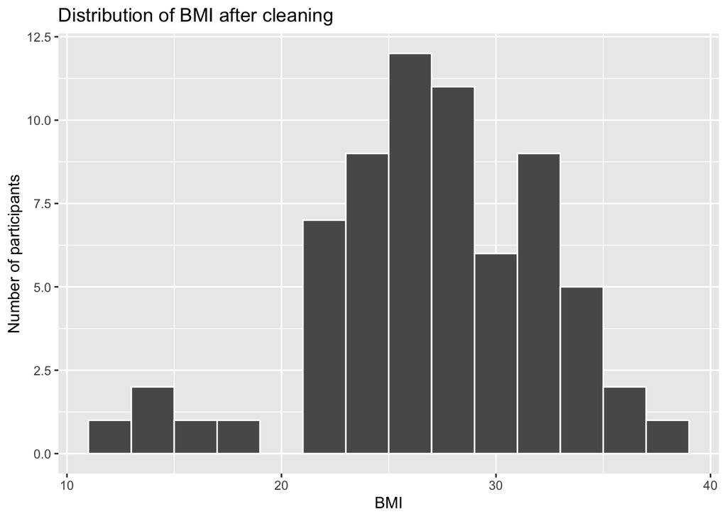

```r
ggplot(clean_data, aes(x = bmi)) +
  geom_histogram(binwidth = 2, colour = "white") +
  labs(
    title = "Distribution of BMI after cleaning",
    x = "BMI",
    y = "Number of participants"
  )
```

Another useful plot is BMI by diabetes status:

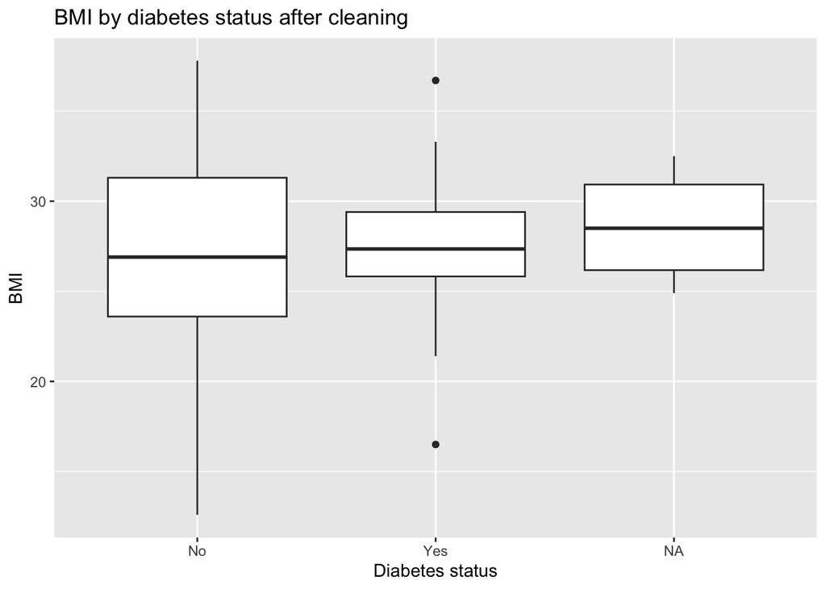

```r
ggplot(clean_data, aes(x = diabetes_status, y = bmi)) +
  geom_boxplot() +
  labs(
    title = "BMI by diabetes status after cleaning",
    x = "Diabetes status",
    y = "BMI"
  )
```

These are not final publication figures. They are quick checks to make sure the cleaned data behave roughly as expected.

## 22. Mini activity

Try repeating the cleaning workflow yourself.

### Task

1. Open the messy dataset.
2. Clean the column names.
3. Count missing values.
4. Find duplicate participant IDs.
5. Standardise `sex`, `smoking_status`, and `diabetes_status`.
6. Convert numeric variables using `parse_number()`.
7. Check for impossible values in age, BMI, blood pressure, HbA1c, and exercise minutes.
8. Replace clearly impossible values with `NA`.
9. Save the cleaned dataset as a new CSV file.

### Reflection questions

- Which variable had the most missing values after cleaning?
- Which values were biologically impossible?
- Which cleaning decisions were obvious?
- Which cleaning decisions would require supervisor input in a real project?
- Why is it risky to manually clean data in Excel without saving the cleaning steps?

## 23. Common beginner mistakes

### Overwriting the raw dataset

Do not save cleaned data over the original file. Keep raw data untouched.

### Removing missing values too early

Do not delete every row with a missing value at the start. First, understand which variables are missing and why.

### Treating all duplicate IDs as errors

A duplicate ID may be an error, but it may also represent repeated visits or follow-up measurements. Always check the study design.

### Cleaning without documenting decisions

If you replace values with `NA`, record why. Your future self will thank you. Future-you is already busy enough.

## 24. What comes next?

Now that we have a cleaned dataset, we can start asking research questions.

In the next article, we can use this cleaned dataset to:

- create a basic Table 1;
- summarise continuous and categorical variables;
- compare groups;
- make clearer figures;
- choose simple statistical tests.

**TipKey takeaway**

Data cleaning is where research analysis becomes trustworthy. Before running statistical tests, make sure each row, column, category, and numeric value means what you think it means.

## Appendix: Beginner glossary

| Term | Meaning |
| --- | --- |
| Raw data | The original dataset before cleaning |
| Cleaned data | A dataset that has been checked, standardised, and prepared for analysis |
| Missing value | A value that is not available, usually shown as `NA` in R |
| Duplicate | A repeated row or repeated participant ID |
| Categorical variable | A variable containing groups or labels, such as sex or smoking status |
| Numeric variable | A variable containing numbers, such as age or BMI |
| `mutate()` | A function used to create or modify columns |
| `case_when()` | A function used to recode values based on conditions |
| `parse_number()` | A function that extracts numbers from text |
| `write_csv()` | A function used to save a dataset as a CSV file |

## Downloadable resources

- `rise_sample_health_data_messy.csv`
- `rise_sample_health_data_cleaned.csv`
- `article_02_cleaning_code.R`
- `data_cleaning_summary.csv`
- `duplicate_participant_report.csv`
- `missing_value_summary.csv`
- `suspicious_values_report.csv`
- `variable_dictionary.csv`